# Alpha_beta_diversity

Naga

## Setup

Loading the microbiome profiles

```
## phyloseq-class experiment-level object
## otu_table()   OTU Table:         [ 9928 taxa and 193 samples ]
## sample_data() Sample Data:       [ 193 samples by 22 sample variables ]
## tax_table()   Taxonomy Table:    [ 9928 taxa by 8 taxonomic ranks ]
## refseq()      DNAStringSet:      [ 9928 reference sequences ]
```

We consider a sample as Clostridium difficile positive if Clostridium difficile was detected either the lab assay or in the microbiome sequencing profiles.

```
## Rows: 193
## Columns: 24
## $ Sample                                 <chr> "CS1_EQ1", "CS10_OV3", "CS100_…
## $ Host_species                           <chr> "Equine", "Ovine", "Canine", "…
## $ Breed                                  <chr> "Oldenburg", NA, "Black and Ta…
## $ Age_reported                           <chr> NA, NA, "1 year", "7 years", "…
## $ Age_group                              <fct> Not applicable, Not applicable…
## $ Age                                    <dbl> NA, NA, 1.0000000, 7.0000000, …
## $ SexCS                                  <fct> MC, M, M, FS, FS, MC, F, F, No…
## $ Sex                                    <fct> M, M, M, F, F, M, F, F, Not kn…
## $ Neutered                               <fct> Yes, No, No, Yes, Yes, Yes, No…
## $ Ab_status                              <fct> Non-treated, Non-treated, Trea…
## $ Ab_type                                <chr> "None reported", NA, "metronid…
## $ Ab_group                               <chr> NA, NA, "Nitroimidazole", "Non…
## $ GI_status                              <fct> Healthy, Healthy, Healthy, GI …
## $ CD_lab                                 <fct> Negative, Negative, Negative, …
## $ CD_toxigenic                           <fct> Negative, Negative, Negative, …
## $ CD_ribotype                            <chr> "Negative", "Negative", "Negat…
## $ Relevant_diagnosis_or_reason_for_visit <chr> "Fever and leukopenia - resolv…
## $ Sample_number                          <int> 1, 10, 100, 101, 102, 103, 104…
## $ Sequence_ID                            <chr> "CS1-EQ1", "CS10", "CS100-CN59…
## $ Year_sequenced                         <fct> 2018, 2017, 2018, 2018, 2018, …
## $ Sample_sum                             <dbl> 19019, 24720, 20789, 21974, 24…
## $ CD_reads                               <dbl> 0, 0, 0, 0, 0, 0, 5, 264, 0, 0…
## $ CD_either                              <fct> Negative, Negative, Negative, …
## $ CD                                     <fct> Negative, Negative, Negative, …
```

Our question is primarily whether CD presence affects the *rest* of the microbiome, so we might want to prune the Cdiff reads before doing our alpha and beta divsity analysis. This pruning will likely make very little difference to the results, because Cdiff tends to be low a very low percentage of the community:

```
##      Min.   1st Qu.    Median      Mean   3rd Qu.      Max.
## 0.0002346 0.0006569 0.0061083 0.0107715 0.0123313 0.0641462
```

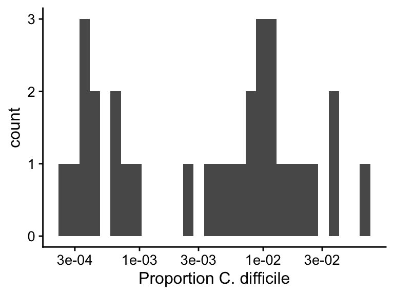

and the alpha and beta diversity measures we use are not sensitive to a low-proportion taxa. However, to confirm that our results are not substantially affected by CD abundance in the profiles, we will run our analyses both ways.

```
##   ASV82 ASV1962 ASV2073
##    TRUE    TRUE    TRUE
```

Convert profiles to proportions, and get versions aggregated to the genus and family ranks

## Alpha and beta diversity across hosts

### Alpha diversity

We use the `diversity()` function in the `vegan` package to calculate the Inverse Simpson diversity index at the ASV, Genus, and Family level and add these to `sample_data(ps)`.

```
##    CS1_EQ1   CS10_OV3 CS100_CN59 CS101_CN60  CS102_FL7 CS103_CN61
##  12.225868   9.147957   5.332248   2.138047   4.033600   8.878530
```

```
##    CS1_EQ1   CS10_OV3 CS100_CN59 CS101_CN60  CS102_FL7 CS103_CN61
##  12.210650  14.551801   5.807628   2.386502   5.091455  10.229674
```

```
##    CS1_EQ1   CS10_OV3 CS100_CN59 CS101_CN60  CS102_FL7 CS103_CN61
##  78.728452  52.421395  17.591846   2.671035  12.818023  13.455389
```

```
## [1] TRUE
```

```
## [1] TRUE
```

For plotting, let’s get a data frame with the sample metadata and the diversity measures gathered into “tidy” form,

```
## # A tibble: 579 x 5
##    Sample     Host_species Index   Rank   Diversity
##    <chr>      <chr>        <fct>   <fct>      <dbl>
##  1 CS1_EQ1    Equine       InvSimp Family     12.2
##  2 CS10_OV3   Ovine        InvSimp Family      9.15
##  3 CS100_CN59 Canine       InvSimp Family      5.33
##  4 CS101_CN60 Canine       InvSimp Family      2.14
##  5 CS102_FL7  Feline       InvSimp Family      4.03
##  6 CS103_CN61 Canine       InvSimp Family      8.88
##  7 CS104_EQ28 Equine       InvSimp Family      9.48
##  8 CS105_EQ29 Equine       InvSimp Family      7.94
##  9 CS106_CN62 Canine       InvSimp Family      7.52
## 10 CS107_EQ30 Equine       InvSimp Family     12.1
## # … with 569 more rows
```

The Inverse Simpson index is not sensitive to rare taxa and so should not be significantly affected by read depth in the range of read depths of our samples. We can confirm by plotting diversity against read depth and making sure there is not an increasing pattern,

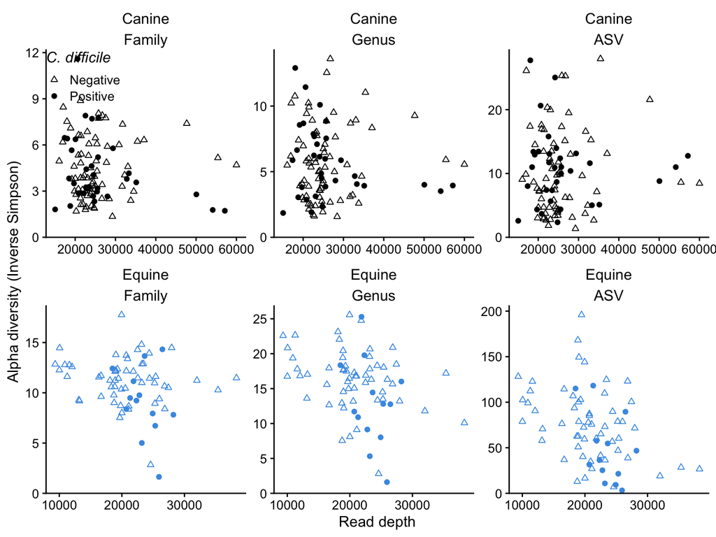

### Beta diversity

We’ll perform NMDS using Bray-Curtis dissimilarity at the ASV level.

```
## *** No convergence -- monoMDS stopping criteria:
##     50: stress ratio > sratmax
```

### Figure for manuscript

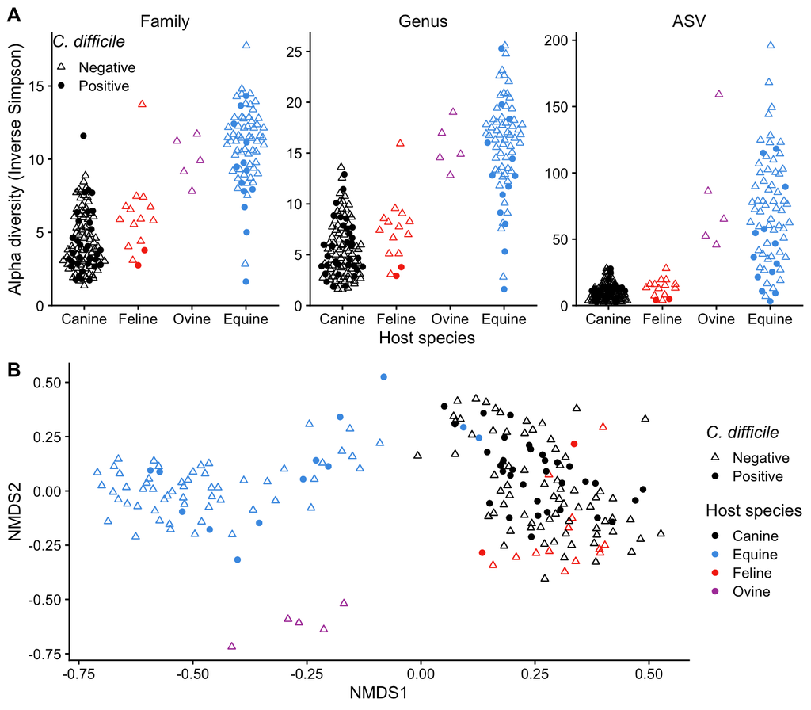

## Alpha diversity and *C. difficile* in canines and equines

Here we test for an association of *C. difficile* with alpha diversity in canines and equines, the only species with a substantial number of CD+ samples,

First, get a data frame subset to just canines and equines,

Create a 2-panel figure, showing diversity in CD- and CD+ samples, at the three taxonomic ranks, for the two hosts,

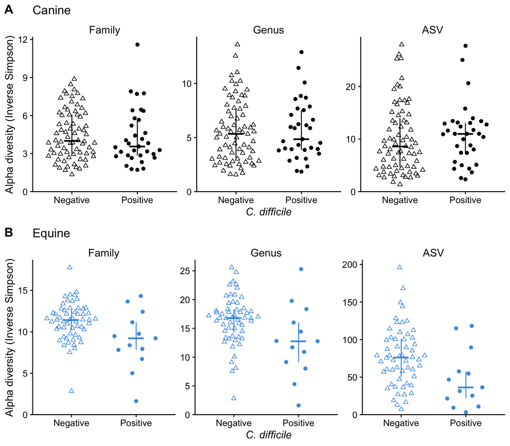

## Beta diversity and *C. difficile* in canines and equines

Here we perform a permanova test using the adonis2 function in vegan to identify if there is a significant difference in the microbiome profiles between CD+ and CD- samples within animal groups canine and equine. As above, we use Bray-Curtis similarity, but we only examine the ASV-level profiles.

```
## Permutation test for adonis under reduced model
## Terms added sequentially (first to last)
## Permutation: free
## Number of permutations: 40000
##
## vegan::adonis2(formula = bray.canine ~ CD, data = df.canine, permutations = 40000)
##           Df SumOfSqs      R2      F   Pr(>F)
## CD         1    0.948 0.02586 2.7074 0.002075 **
## Residual 102   35.718 0.97414
## Total    103   36.666 1.00000
## ---
## Signif. codes:  0 '***' 0.001 '**' 0.01 '*' 0.05 '.' 0.1 ' ' 1
```

```
## Permutation test for adonis under reduced model
## Terms added sequentially (first to last)
## Permutation: free
## Number of permutations: 40000
##
## vegan::adonis2(formula = bray.equine ~ CD, data = df.equine, permutations = 40000)
##          Df SumOfSqs      R2      F   Pr(>F)
## CD        1    0.789 0.02998 2.0705 0.000275 ***
## Residual 67   25.530 0.97002
## Total    68   26.319 1.00000
## ---
## Signif. codes:  0 '***' 0.001 '**' 0.01 '*' 0.05 '.' 0.1 ' ' 1
```